# Homework 1

```python
# Python 3.8.10
%matplotlib inline
```

```python
import numpy as np
import os                                     # Only to save the pics in specified directory
import matplotlib.pyplot as plt
```

## Problem 1

### 1.1 Inner Product of Vectors

$$ <\mathbf{y}, \mathbf{z}> = \left[\begin{array}{ccc} 0 & 1 & 0 \\ \end{array}\right] \left[\begin{array}{c} 5 \\ 6 \\ 0 \end{array}\right] = 6 $$

### 1.2 Inner Product of Matrix and vector

$$ \mathbf{X}\cdot\mathbf{y} = \left[\begin{array}{ccc} 1 & 2 & 4 \\ 4 & 1 & 2 \\ 0 & 1 & 2 \end{array}\right] = \left[\begin{array}{c} 2 \\ 1 \\ 1 \end{array}\right] $$

### 1.3 Inverse of the Matrix

To see if the matrix $\mathbf{X}$ is invertiable, we can compute its determinant

$$ \text{det}(\mathbf{X}) = (2 + 0 + 16) - (16 + 0 + 2) = 0, $$

for the determinant of $\mathbf{X}$ is 0, the matrix has no inverse.

### 1.4 Solution of a Linear Functions System

The given function can be rewritten as follows: $$ \mathbf{x} = \mathbf{X}^{-1} \mathbf{y} ~~~~~~ \text{and} ~~~~~~ \mathbf{x} = \mathbf{X}^{-1} \mathbf{z} $$ as already seen, matrix $\mathbf{X}$ has no inverse, the functions has no solution.

### 1.5 Eigenvectors and Eigenvalues

Let $\vec{x}$ and $\lambda$ be the eigenvector and eigenvalue for $\mathbf{Y}$, we have: $$ \mathbf{Y} \cdot \vec{x} = \lambda \cdot \vec{x} \\ \Rightarrow (\mathbf{Y} - \lambda \mathbf{I}) \vec{x} = 0 \\ \Rightarrow \text{det}(\mathbf{Y} - \lambda \mathbf{I}) = 0 $$ which leads to: $$ (1 - \lambda)^2 -4 = 0 ~~~~~~ \Rightarrow ~~~~~~ \lambda_1 = 3;~\lambda_2 = -1 \\ \vec{x}_1 = \left[\begin{array}{c} 1 \\ 1 \end{array}\right], ~~~~~~ \vec{x}_2 = \left[\begin{array}{c} 1 \\ -1 \end{array}\right] $$

### 1.6 Partial Derivative and Gradient

The partial derivative of $f$ over $x_1$ can be given as $$ \begin{align*} \frac{\partial f(\mathbf{x})}{\partial(x_1)} &= 2(y - \mathbf{z}^\top \mathbf{x}) \cdot \frac{\partial y - \mathbf{z}^\top \mathbf{x}}{\partial x_1} \\ &= 2 z_1 (\mathbf{z}^\top \mathbf{x} - y) \end{align*} $$

The gradient of $f$ over $\mathbf{x}$ is $$ \begin{align*} \triangledown_\mathbf{x} f(\mathbf{x}) = 2 \mathbf{z} (\mathbf{z}^\top \mathbf{x} - y) \end{align*} $$

### 1.7 Minimizer

To find the minimizer of $f$, we have to find the $\mathbf{x}$ such that $\triangledown_{\mathbf{x}}f(\mathbf{x}) = 0$

## Problem 2

### 2.1 Mean and Variance

The sample mean is

$$ \frac{5}{10} = 0.5 $$

and sample variance is

$$ \begin{align*} \text{var} &= \frac{1}{10} \sum_{i=1}^{n}(x_i - 0.5)^2 \\ &= \frac{1}{10} \sum_{i=1}^{10}0.25^2 \\ &= 0.25 \end{align*} $$

### 2.2 Probability of Observation if $p = 0.5$

The probability of observing the given data under the specified circumstance can be calculated as

$$ C\binom{10}{5}*2^{-10} \approx 0.246 $$

### 2.3 $p$ that Maximize the Observation

Let p be the probability to be found, we have:

$$ P = p^5 \times (1-p)^5 $$

and thus

$$ \frac{\partial P}{\partial p} = 5p^4 \times (1-p)^5 \times 5(1-p)^4 $$

to solve the problm, let $\frac{\partial P}{\partial p} = 0$, we have

$$ \begin{align*} 0 &= 5p^4 \times (1-p)^5 \times 5(1-p)^4 \\ (1 - p)^5 &= p(1 - p)^4 \\ (1 - p) &= p \\ p &= 0.5 \end{align*} $$

### 2.4 Distribution of a Combined Variable

$X + aY$ is still a Gaussian random variable

### 2.5 Inpendency Verification of a Combined Variable

The new variable $Z=XY$ is independent on $Y$.

Because $Y$ is a random varible with $Y \in \left\{1, -1\right\}$, if $Y = 1$ it is intuitive that $Z = X$. If $Y = -1$, even though we have $Z = -X$, but since $X\sim\mathcal{N}(0, \sigma^2)$, $X$ is symmetric around $0$, we can still say that $Z = X$.

## Problem 3

### 3.1

#### (a)

Both, the answer depends on the choice of $C$, to the given functions we can apply the change of base fomular for logarithms, which gives us

$$ \text{log}_2(x) = \frac{\text{log}_e(x)}{\text{log}_e(2)}, $$

indicating if $C = \frac{1}{\text{log}_e(2)}$, then $f(x) = O(g(x))$, and if $C = \text{log}_e(2)$, $g(x) = O(f(x))$

#### (b)

Assuming $f(x) = O(g(x))$, which gives us

$$ \begin{align*} |e^x| &\le C2^x \\ \text{log}_e(e^x) &\le \text{log}_e(C2^x) \\ x &\le \text{log}_e(C2^x) \\ &\le \text{log}_eC + log_e2^x \\ &\le \text{log}_eC + xlog_e2 \end{align*} $$

for $log_e2 < 1 $, there exists no valid $x_0$ and $C$.

Likely we can also asumme $g(x) = O(f(x))$, and the following should hold

$$ \begin{align*} |2^x| &\le Ce^x \\ \text{log}_2(2^x) &\le \text{log}_2(Ce^x) \\ x &\le \text{log}_2(Ce^x) \\ &\le \text{log}_2C + log_2e^x \\ &\le \text{log}_2C + xlog_2e \end{align*} $$

The inequality can be true if we simply set $C = 1$ because $\text{log}_2e > 1$

Thus for this task, $g(x) = O(f(x))$.

#### (c)

Assuming $f(x) = O(g(x))$, which gives us

$$ \begin{align*} |x| &\le C(10x + \text{log}_2x) \\ &\le (10Cx + C\text{log}_2x) \\ \end{align*} $$

valid solution can be found if we simply set $C = 1$, so $f(x) = O(g(x))$.

### 3.2

The calculation goes:

$$ \mathbf{X}\mathbf{y} \mapsto \mathbb{R}^{m \times n}\times \mathbb{R}^{n} $$

in every array of $\mathbf{X}$ there are $n$ multiplications and $n-1$ additions, and we have $m$ such procedures, so we have the complexity of $O(m(2n-1))$

## Problem 4

### 4.1 Scatter Plot

create the required $x$ array

```python
x = np.arange(0, 1, 0.001)
print("Size of the x:", x.size)
```

```
Size of the x: 1000
```

genetate $\epsilon_i$ following gaussian distribution

```python
epsilon = np.random.normal(0, 0.25, 1000)
print("Size of the epsilon:", epsilon.size)
```

```
Size of the epsilon: 1000
```

compute $y$

```python
y = x + epsilon
```

make the scatter plot

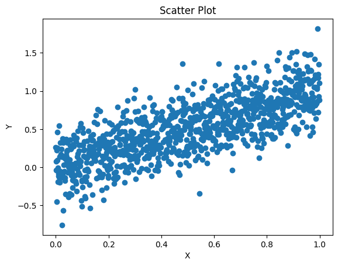

```python
plt.scatter(x, y)
plt.xlabel('X')
plt.ylabel('Y')
plt.title('Scatter Plot')
plt.savefig("/home/yueyangzhang/TUM/MLO/Problem4_1.png")
```

### 4.2 Compute $a$ and Plot

The minimum of $f(a) = \sum_{i=1}^{n} (x_i a -y_i)^2$ can be represented as $\text{argmin}_a \sum_{i=1}^{n} (x_i a -y_i)^2$, regarding to proposition 1 in lecture_note_1_2, a can be calculated as $(\underline{x}^\top \underline{x})^{-1} \underline{x}^\top \underline{y}$

```python
a = np.dot(pow(np.dot(x, x), -1), np.dot(x, y))
print("minimizer of f w.r.t. a is a =", a)
```

```
minimizer of f w.r.t. a is a = 1.0054750084608437
```

add the estimated linear model to the data

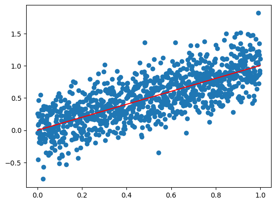

```python
g = np.dot(a, x)
plt.scatter(x, y)
plt.plot(x, g, color = "red")
# plt.savefig("/home/yueyangzhang/TUM/MLO/Problem4_2.png")
```

### 4.3 Close Form Solution

The gievn function can be rewritten as:

$$ p_d(\mathbf{x}) = \mathbf{X} \cdot \mathbf{a} $$

where

$$ \mathbf{X} = \left[\begin{array}{ccc} x_1^0 & \cdots & x_1^d \\ \vdots & \ddots & \vdots \\ x_n^0 & \cdots & x_n^d \end{array}\right]\in \mathbb{R}^{n \times (d+1)} $$

and $a = [a_0 ~ \cdots ~ a_d]^\top \in \mathbb{R}^{d+1}$. Consequrntly, $f(\mathbf{a})$ can be written as:

$$ f(\mathbf{a}) = \left\| \mathbf{X} \mathbf{a}^\top - y \right\|_2^2 $$

and thus the close form solution can be refered to the lecture note and given as $$ \mathbf{a} = (\mathbf{X}^\top \mathbf{X})^{-1} \mathbf{X}^\top y $$

### 4.4 Upgraded $y$ and Plot

as requested change the ground truth of $y$, denoted as $y_1$

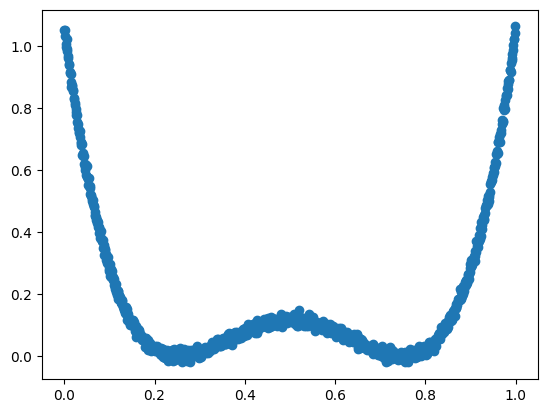

```python
xi = np.random.normal(0, 0.01, 1000)

y_1 =  30 * ((x - 0.25) ** 2 * (x - 0.75) ** 2) + xi
plt.scatter(x, y_1)
```

For the new curve, applies the closed form of the least square solution

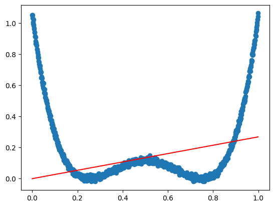

```python
a_1 = np.dot(pow(np.dot(x, x), -1), np.dot(x, y_1))
g_1 = a_1 * x
plt.scatter(x, y_1)
plt.plot(x, g_1, color = "red")
# plt.savefig("/home/yueyangzhang/TUM/MLO/Problem4_4.png")
```

## Problem 5

### 5.1 Perpandicularity Proof

Set $b=0$, we can get $<\mathbf{w}, \mathbf{x}> = 0$, in this case $\mathbf{w} \perp \mathbf{x}$. We can further translate $\mathbf{x}$ by an arbitrary distance $\mathbf{a}$, because this is just a pure translation, we get $<\mathbf{w}, (\mathbf{x} + \mathbf{a})> = 0$, alternatively $$ \mathbf{w}^\top (\mathbf{x}+\mathbf{a}) = 0 \\ \Rightarrow ~ \mathbf{w}^\top \mathbf{x} + \mathbf{w}^\top \mathbf{a} = 0 , $$ for that $\mathbf{a}$ is arbitrary, we can let $b = \mathbf{w}^\top \mathbf{a}$, the result is still a translation of $\mathbf{x}$, so the relationship holds $\mathbf{w} \perp \mathbf{x}$

### 5.2 Distance

Follow the steps in 5.1 and w.l.o.g. let $\mathbf{a}$ perpandicular to the hyperplane, which is the shortest vector between $\mathbf{w}$ and $\mathbf{x}$, the distance can be calculated as $\text{distance} = \left\| \mathbf{a} \right\|$, i.e.,

$$ \left\| \mathbf{a} \right\| = \frac{\left\| \mathbf{b} \right\|}{\left\| \mathbf{w} \right\|} $$

## Problem 6

### 6.1 Variance

$$ \begin{align*} \text{Var}(Y) &= a^2 \times \text{Var}(X) \\ &= a^2 \sigma^2 \end{align*} $$

### 6.2 (a) CLT

If n is large enough, according to the Central Limit Theorem (CLT), Y is converging to a standard normal distribution, i.e. $Y \sim \mathcal{N}(0, \sigma^2)$.

### 6.2 (b) Interval

Follow the result of 6.2 (a) we have $Y \sim \mathcal{N}(0, 0.25)$ and thus $Y \sim \mathcal{N}(0, 1)$. For such a distribution, $95\%$ lies in the inverval $(-1.96, 1.96)$. For the solution, the interval is given as $$ \frac{1}{n}(\frac{n}{2} \pm 1.96 \cdot \frac{\sqrt{n}}{2}) ~~~~ \Rightarrow ~~~~ (0.49 0.51) $$

### 6.3 Test and Sickness

Define the following events

1. A: person is sick
2. B: test result is positive
3. C: person is health
4. D: test result is negative

and according to the given information we have $P(A) = 0.5\%$, $P(B|A) = 95\%$ and $P(B|C) = 10\%$

#### (a)

To be found is $P(B)$

$$ \begin{align*} P{B} &= P(B|A)P(A)+P(B|C)P(C) \\ &= 0.005 \times 0.95 + (1-0.005) \times 0.1 \\ &\approx 10\% \end{align*} $$

#### (b)

To be found is $P(A|B)$, we can utilize Bayes' rule

$$ \begin{align*} P{A|B} &= \frac{P(B|A)P(A)}{P(B)} \\ &= \frac{0.95 \times 0.005}{0.1} \\ &\approx 4\% \end{align*} $$

#### (c)

To be found is $P(C|D)$

$$ \begin{align*} P(C|D) &= 1-P(A|D) \\ & = 1 - \frac{P(D|A)P(A)}{P(D)} & = 1 - \frac{(1-P(B|A))P(A)}{1-P(B)} &\approx 99\% \end{align*} $$

#### (d)

To be found can be formulated as

$$ \begin{align*} P(B|C)P(C) + P(D|A)P(A) &= 0.1(1-0.005) + (1-0.95) 0.005 \\ & \approx 10\% \end{align*} $$

## Problem 7

### 7.1 Global Minimum of Convex Function

Let $\mathbf{x}^*$ be the local minimum of $f$, assume it is not the global minimum, which meams there exist a $\mathbf{x}_0$ such that $f(\mathbf{x}_0) < f(\mathbf{x}^*)$.

By definition, for a convex function, for any $\theta \in (0,1)$ we have

$$ \begin{align*} f(\theta \mathbf{x}^* + (1-\theta)\mathbf{x}_0) &\le \theta f(\mathbf{x}^*) + (1-\theta)f(\mathbf{x}_0) \\ &< \theta f(\mathbf{x}^*) + (1-\theta)f(\mathbf{x}^*)\\ \Rightarrow f(\theta \mathbf{x}^* + (1-\theta)\mathbf{x}_0) &< f(\mathbf{x}^*) \end{align*} $$

Now, if $\theta\to 1$, $\theta \mathbf{x}^* + (1-\theta)\mathbf{x}_0 \to \mathbf{x}^*$, in such case, $\mathbf{x}^*$ cannot be the local minimum neither.

Therefore local minimun $\mathbf{x}^*$ of a convex function must also be the global minimum.